# Spatial Heterogeneity and Spatially Varying Coefficients

Jialiang

2023-03-23

## Preparation

I refrained the codes for data wrangling procress from apperaing in the html.

## Spatial Heterohegeneity

### Geographically Weighted Regression (GWR)

We do a basic GWR using the `GWmodel` package in R. There are several steps to take.

1. Estimate an optimal bandwidth (based on the model fitness), which will define the local neighborhoods.
2. Do the estimation for each feature(unit) in our data by including the variables of its neighbors.

#### Choose an optimal bandwidth

We can use `GWmodel::bw.gwr` for automatic bandwidth selection to calibrate a basic GWR model.

Again I am using the cross sectional data from 2015. I haven’t found a good way to deal with panel data. More exploration is in need.

```r
# Estimate an optimal bandwidth, using great circle distances
# library(GWmodel)
bwVal <- GWmodel::bw.gwr(log(tarvl+1) ~ CPIp +
                          log(1+salary) +
                          log(1+area) + log(1+pop) +
                          log(1+railway),
                         data = filter2015 %>% sf::as_Spatial(),
                         approach = 'AICc', kernel = 'bisquare',
                         longlat = TRUE,
                         adaptive = TRUE)
```

```
## Adaptive bandwidth (number of nearest neighbours): 182 AICc value: 492.9291
## Adaptive bandwidth (number of nearest neighbours): 120 AICc value: 483.4186
## Adaptive bandwidth (number of nearest neighbours): 81 AICc value: 478.7887
## Adaptive bandwidth (number of nearest neighbours): 57 AICc value: 483.9822
## Adaptive bandwidth (number of nearest neighbours): 95 AICc value: 480.5789
## Adaptive bandwidth (number of nearest neighbours): 71 AICc value: 479.4585
## Adaptive bandwidth (number of nearest neighbours): 86 AICc value: 478.9267
## Adaptive bandwidth (number of nearest neighbours): 76 AICc value: 479.6419
## Adaptive bandwidth (number of nearest neighbours): 82 AICc value: 478.4225
## Adaptive bandwidth (number of nearest neighbours): 84 AICc value: 478.2081
## Adaptive bandwidth (number of nearest neighbours): 84 AICc value: 478.2081
```

This gives us an optimal bandwidth of $84$ (number of nearest neighbours). Now we run the basic GWR.

```r
## the basic GWR regression
## library(GWmodel)
gwr.tarvl2015 <- gwr.basic(log(tarvl+1) ~ CPIp +
                          log(1+salary) +
                          log(1+area) + log(1+pop) +
                          log(1+railway),
                         data = filter2015 %>% sf::as_Spatial(),
                     bw = bwVal, kernel = "bisquare", adaptive = TRUE)
```

Show the results.

```r
print(gwr.tarvl2015)
```

```
##    *                       Package   GWmodel                             *
##    Program starts at: 2023-03-23 16:48:00
##    Call:
##    gwr.basic(formula = log(tarvl + 1) ~ CPIp + log(1 + salary) +
##     log(1 + area) + log(1 + pop) + log(1 + railway), data = filter2015 %>%
##     sf::as_Spatial(), bw = bwVal, kernel = "bisquare", adaptive = TRUE)
##
##    Dependent (y) variable:  tarvl
##    Independent variables:  CPIp salary area pop railway
##    Number of data points: 283
##    *                    Results of Global Regression                     *
##
##    Call:
##     lm(formula = formula, data = data)
##
##    Residuals:
##     Min      1Q  Median      3Q     Max
## -1.9417 -0.4088  0.0953  0.4481  1.4124
##
##    Coefficients:
##                     Estimate Std. Error t value Pr(>|t|)
##    (Intercept)      -7.50398    8.56234  -0.876 0.381576
##    CPIp              0.01822    0.08085   0.225 0.821858
##    log(1 + salary)   0.89979    0.24735   3.638 0.000328 ***
##    log(1 + area)    -0.07449    0.04732  -1.574 0.116613
##    log(1 + pop)      0.72955    0.06337  11.512  < 2e-16 ***
##    log(1 + railway)  0.09210    0.04331   2.127 0.034337 *
##
##    ---Significance stars
##    Signif. codes:  0 '***' 0.001 '**' 0.01 '*' 0.05 '.' 0.1 ' ' 1
##    Residual standard error: 0.6335 on 277 degrees of freedom
##    Multiple R-squared: 0.5035
##    Adjusted R-squared: 0.4946
##    F-statistic: 56.19 on 5 and 277 DF,  p-value: < 2.2e-16
##    ***Extra Diagnostic information
##    Residual sum of squares: 111.1624
##    Sigma(hat): 0.6289641
##    AIC:  552.6686
##    AICc:  553.0759
##    BIC:  334.7048
```

[output cut: 13 more lines]

```
##    log(1 + area)     -0.4799990  -0.1684089   0.1173147   0.2400199  0.6298
##    log(1 + pop)      -0.1970362   0.1595202   0.3776071   0.8182101  1.3914
##    log(1 + railway)  -0.0174069   0.0955775   0.1598437   0.2223779  0.3785
##    ************************Diagnostic information*************************
##    Number of data points: 283
##    Effective number of parameters (2trace(S) - trace(S'S)): 63.47525
##    Effective degrees of freedom (n-2trace(S) + trace(S'S)): 219.5247
##    AICc (GWR book, Fotheringham, et al. 2002, p. 61, eq 2.33): 474.7843
##    AIC (GWR book, Fotheringham, et al. 2002,GWR p. 96, eq. 4.22): 401.6678
##    BIC (GWR book, Fotheringham, et al. 2002,GWR p. 61, eq. 2.34): 346.6106
##    Residual sum of squares: 57.59902
##    R-square value:  0.7427583
##    Adjusted R-square value:  0.6680369
##
##    Program stops at: 2023-03-23 16:48:01
```

The Adjusted R-squared increased quite a lot. We can examine the spatial variations of the estimated model coefficients.

This show how the coefficients of the local salary change over space.

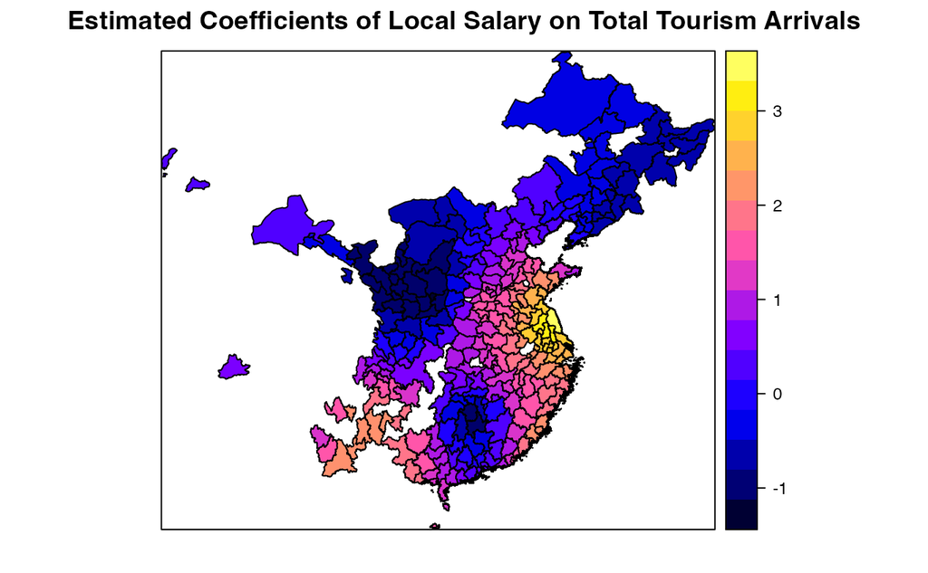

```r
plotcoefsalary <- spplot(spGWR, 'coefsalary', main="Estimated Coefficients of Local Salary on Total Tourism Arrivals")
plotcoefsalary
```

But this variable is not signficiant everywhere, see the following figure.

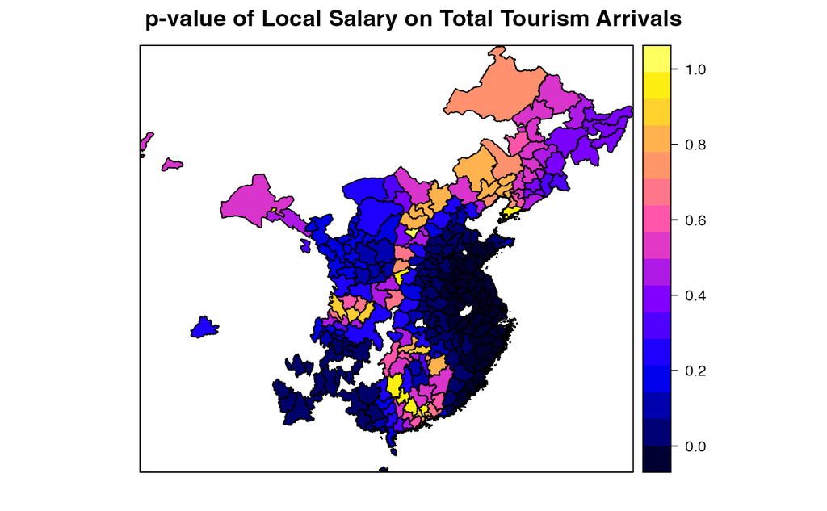

```r
plotpsalary <- spplot(spGWR, 'psalary', main="p-value of Local Salary on Total Tourism Arrivals")
plotpsalary
```

## Summary

The effect of local salary on total tourism arrivals shows a strong geographical pattern:

Statically, the coefficient is not significant in the middle and northeast part of China. Economically, they are positive in most of the areas, but there is a strong negative effect in the upper middle area (although not statically significant at a $10 \%$ level.)

Things to address later on.

1. Find a way to use panel data.
2. Again. Endogeneity – so is there a GWR-GWR-SL(spatial lag) 2SLS model we can use?
3. The optimal number of NN calibrated here is $84$, our old NN was 4 or 5 in the previous document, am I being too conservative? Try increase the number of neighbors.